# Unsupervised_clustering_methods.Rmd

```r
#It's beneficial to use another method, to validate your results. The main issue here is that PCA works best with more samples than dimensions, so with 21,800 probes it would be best either to have >21800 samples or to only select the top ~100 expressed genes and reduce dimensionality from there.
prcomp <- prcomp(data_for_PCA, retx = TRUE, center = TRUE, scale. = FALSE,
                     tol = NULL, rank. = NULL)
```

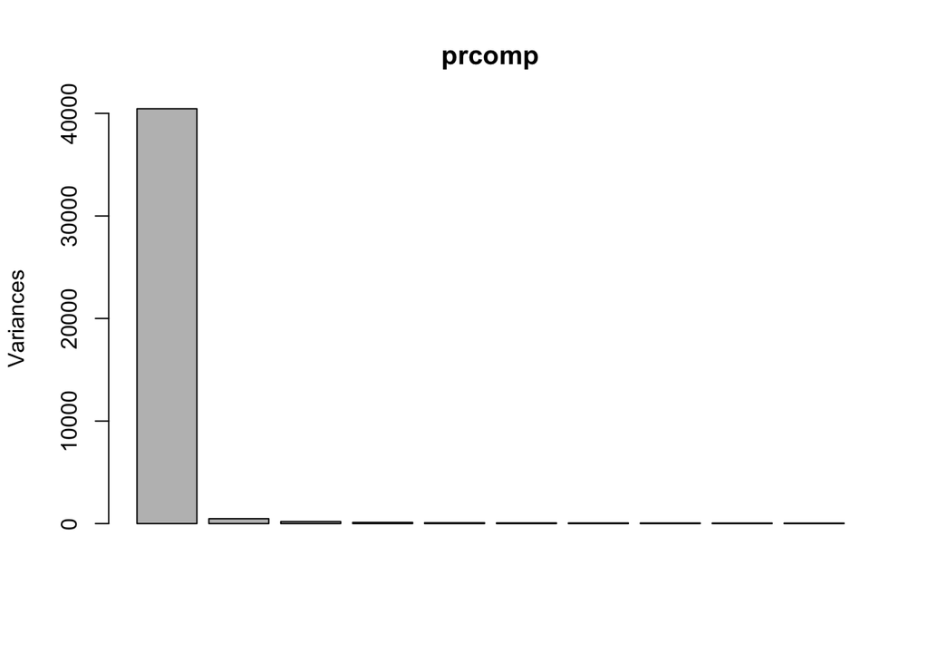

```r
plot(prcomp)
```

[output not shown]

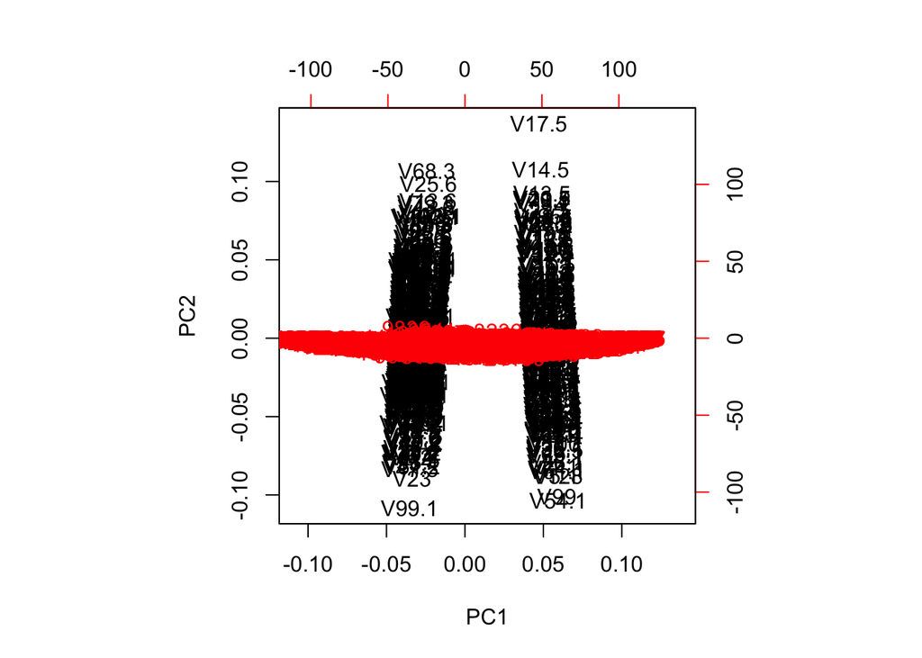

```r
biplot(prcomp)
```

## NMF

NMF stands for non-negative matrix factorisation and is employed in image and text reduction. Two matrices are calculated that muultiply to approximately the original matrix; one of the main methods used to iteratively calculate the matrices is linear regression.

```r
suppressPackageStartupMessages(library(NMF))
aout <- nmf(expressionData,2)
aout.3 <- nmf(expressionData,3)
aout.4 <- nmf(expressionData,4)

#The W and H variables within the 'fit' parameter indicate the matrix breakdown
w <- aout@fit@W
dim(w)
```

```
## [1] 21800     2
```

```r
h <- aout@fit@H
dim(h)
```

```
## [1]   2 618
```

```r
fit(aout)
```

```
## <Object of class:NMFstd>
## features: 21800
## basis/rank: 2
## samples: 618
```

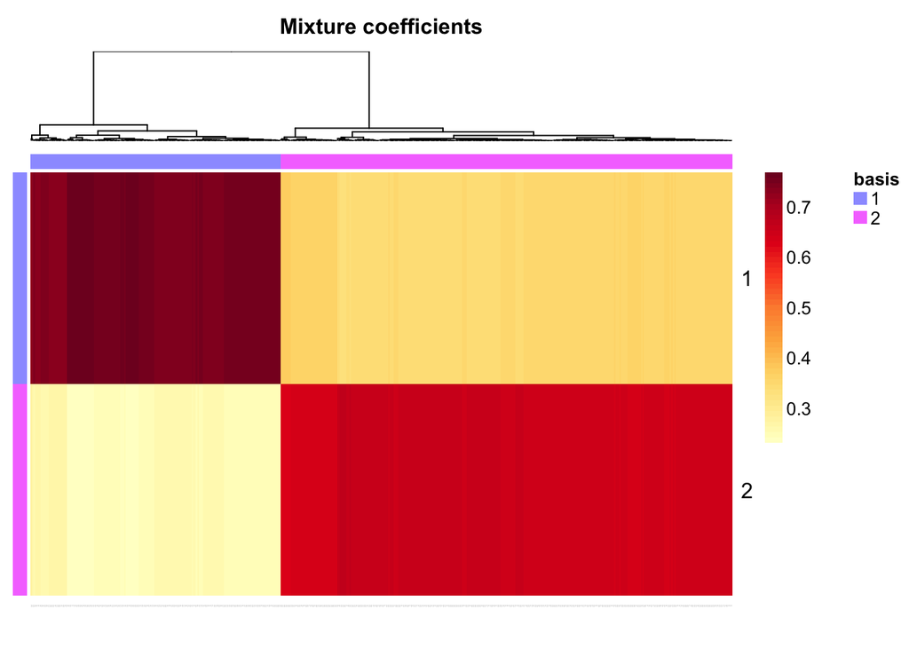

```r
#mtrnew@grey <- approxa
coefmap(aout)
```

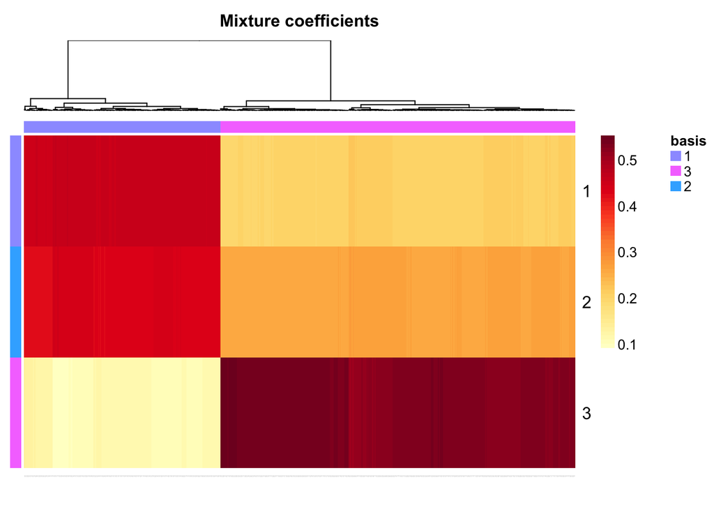

```r
coefmap(aout.3)
```

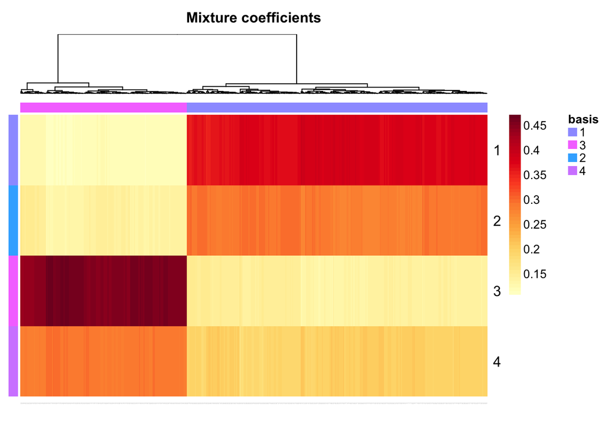

```r
coefmap(aout.4)
```

## Hierarchical clustering

Hierarchical clustering builds a relationship between samples from the bottom up, i.e. from the starting belief that all samples are separate and not related to one another. Each point is this a cluster. The two nearest clusters are identified and combined. Depending on how ‘nearest’ is defined, various different methods and endpoints are used: - Find the maximum possible distance between points belonging to two different clusters = complete linkage clustering - Find the minimum possible distance between points belonging to two different clusters = single linkage clustering - Find all possible pairwise distances for points belonging to two different clusters and then calculate the average = mean linkage clustering - Find the centroid of each cluster and calculate the distance between centroids of two clusters = centroid linkage clustering

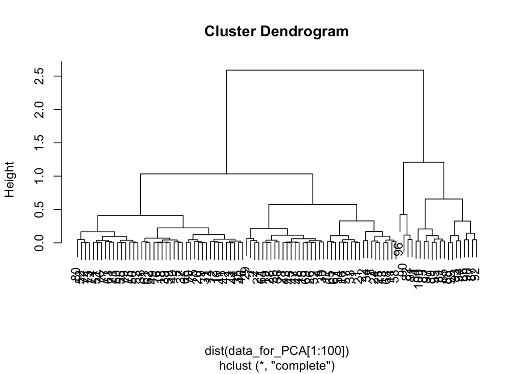

```r
clusters <- hclust(dist(data_for_PCA[1:100]))
plot(clusters)
```